# Risk Factor Analysis

## Outcome Variable

**Outcome Variable:** sstunted

## Predictor Variables

**Intervention Variable:** predfeed3

**Adjustment Set:**

- arm
- sex
- month
- brthmon
- W_mage
- meducyrs
- feducyrs
- hhwealth_quart
- hfoodsec
- W_mhtcm
- W_mwtkg
- W_mbmi
- vagbrth
- W_gagebrth
- W_birthwt
- W_birthlen
- W_nrooms
- W_nchldlt5
- W_parity
- impfloor
- impsan
- safeh20
- delta_W_mage
- delta_meducyrs
- delta_feducyrs
- delta_hhwealth_quart
- delta_hfoodsec
- delta_W_mhtcm
- delta_W_mwtkg
- delta_W_mbmi
- delta_vagbrth
- delta_W_gagebrth
- delta_W_birthwt
- delta_W_birthlen
- delta_W_nrooms
- delta_W_nchldlt5
- delta_W_parity
- delta_impfloor
- delta_impsan
- delta_safeh20

## Stratifying Variables

The analysis was stratified on these variable(s):

- agecat
- studyid
- country

## Data Summary

| agecat | studyid | country | predfeed3 | sstunted | n_cell | n |
| --- | --- | --- | --- | --- | --- | --- |
| Birth | EE | PAKISTAN | 1 | 0 | 28 | 35 |
| Birth | EE | PAKISTAN | 1 | 1 | 7 | 35 |
| Birth | EE | PAKISTAN | 0 | 0 | 0 | 35 |
| Birth | EE | PAKISTAN | 0 | 1 | 0 | 35 |
| Birth | GMS-Nepal | NEPAL | 1 | 0 | 367 | 458 |
| Birth | GMS-Nepal | NEPAL | 1 | 1 | 13 | 458 |
| Birth | GMS-Nepal | NEPAL | 0 | 0 | 73 | 458 |
| Birth | GMS-Nepal | NEPAL | 0 | 1 | 5 | 458 |
| Birth | JiVitA-3 | BANGLADESH | 1 | 0 | 10708 | 13276 |
| Birth | JiVitA-3 | BANGLADESH | 1 | 1 | 1309 | 13276 |
| Birth | JiVitA-3 | BANGLADESH | 0 | 0 | 1116 | 13276 |
| Birth | JiVitA-3 | BANGLADESH | 0 | 1 | 143 | 13276 |
| Birth | JiVitA-4 | BANGLADESH | 1 | 0 | 97 | 116 |
| Birth | JiVitA-4 | BANGLADESH | 1 | 1 | 8 | 116 |
| Birth | JiVitA-4 | BANGLADESH | 0 | 0 | 9 | 116 |
| Birth | JiVitA-4 | BANGLADESH | 0 | 1 | 2 | 116 |
| Birth | MAL-ED | BANGLADESH | 1 | 0 | 169 | 215 |
| Birth | MAL-ED | BANGLADESH | 1 | 1 | 7 | 215 |
| Birth | MAL-ED | BANGLADESH | 0 | 0 | 39 | 215 |
| Birth | MAL-ED | BANGLADESH | 0 | 1 | 0 | 215 |
| Birth | MAL-ED | BRAZIL | 1 | 0 | 23 | 57 |
| Birth | MAL-ED | BRAZIL | 1 | 1 | 1 | 57 |
| Birth | MAL-ED | BRAZIL | 0 | 0 | 32 | 57 |
| Birth | MAL-ED | BRAZIL | 0 | 1 | 1 | 57 |
| Birth | MAL-ED | INDIA | 1 | 0 | 27 | 41 |
| Birth | MAL-ED | INDIA | 1 | 1 | 2 | 41 |
| Birth | MAL-ED | INDIA | 0 | 0 | 12 | 41 |
| Birth | MAL-ED | INDIA | 0 | 1 | 0 | 41 |
| Birth | MAL-ED | NEPAL | 1 | 0 | 14 | 26 |
| Birth | MAL-ED | NEPAL | 1 | 1 | 0 | 26 |

[output cut: 102 more lines]

The following strata were considered:

- agecat: 24 months, studyid: EE, country: PAKISTAN
- agecat: 24 months, studyid: GMS-Nepal, country: NEPAL
- agecat: 24 months, studyid: JiVitA-3, country: BANGLADESH
- agecat: 24 months, studyid: JiVitA-4, country: BANGLADESH
- agecat: 24 months, studyid: MAL-ED, country: BANGLADESH
- agecat: 24 months, studyid: MAL-ED, country: BRAZIL
- agecat: 24 months, studyid: MAL-ED, country: INDIA
- agecat: 24 months, studyid: MAL-ED, country: NEPAL
- agecat: 24 months, studyid: MAL-ED, country: PERU
- agecat: 24 months, studyid: MAL-ED, country: SOUTH AFRICA
- agecat: 24 months, studyid: MAL-ED, country: TANZANIA, UNITED REPUBLIC OF
- agecat: 6 months, studyid: EE, country: PAKISTAN
- agecat: 6 months, studyid: GMS-Nepal, country: NEPAL
- agecat: 6 months, studyid: JiVitA-3, country: BANGLADESH
- agecat: 6 months, studyid: JiVitA-4, country: BANGLADESH
- agecat: 6 months, studyid: MAL-ED, country: BANGLADESH
- agecat: 6 months, studyid: MAL-ED, country: BRAZIL
- agecat: 6 months, studyid: MAL-ED, country: INDIA
- agecat: 6 months, studyid: MAL-ED, country: NEPAL
- agecat: 6 months, studyid: MAL-ED, country: PERU
- agecat: 6 months, studyid: MAL-ED, country: SOUTH AFRICA
- agecat: 6 months, studyid: MAL-ED, country: TANZANIA, UNITED REPUBLIC OF
- agecat: Birth, studyid: EE, country: PAKISTAN
- agecat: Birth, studyid: GMS-Nepal, country: NEPAL
- agecat: Birth, studyid: JiVitA-3, country: BANGLADESH
- agecat: Birth, studyid: JiVitA-4, country: BANGLADESH
- agecat: Birth, studyid: MAL-ED, country: BANGLADESH
- agecat: Birth, studyid: MAL-ED, country: BRAZIL
- agecat: Birth, studyid: MAL-ED, country: INDIA
- agecat: Birth, studyid: MAL-ED, country: NEPAL
- agecat: Birth, studyid: MAL-ED, country: PERU
- agecat: Birth, studyid: MAL-ED, country: SOUTH AFRICA
- agecat: Birth, studyid: MAL-ED, country: TANZANIA, UNITED REPUBLIC OF

### Dropped Strata

Some strata were dropped due to rare outcomes:

- agecat: Birth, studyid: EE, country: PAKISTAN
- agecat: Birth, studyid: JiVitA-4, country: BANGLADESH
- agecat: Birth, studyid: MAL-ED, country: BANGLADESH
- agecat: Birth, studyid: MAL-ED, country: BRAZIL
- agecat: Birth, studyid: MAL-ED, country: INDIA
- agecat: Birth, studyid: MAL-ED, country: NEPAL
- agecat: Birth, studyid: MAL-ED, country: PERU
- agecat: Birth, studyid: MAL-ED, country: SOUTH AFRICA
- agecat: Birth, studyid: MAL-ED, country: TANZANIA, UNITED REPUBLIC OF
- agecat: 6 months, studyid: EE, country: PAKISTAN
- agecat: 6 months, studyid: JiVitA-4, country: BANGLADESH
- agecat: 6 months, studyid: MAL-ED, country: BANGLADESH
- agecat: 6 months, studyid: MAL-ED, country: BRAZIL
- agecat: 6 months, studyid: MAL-ED, country: INDIA
- agecat: 6 months, studyid: MAL-ED, country: NEPAL
- agecat: 6 months, studyid: MAL-ED, country: PERU
- agecat: 6 months, studyid: MAL-ED, country: SOUTH AFRICA
- agecat: 6 months, studyid: MAL-ED, country: TANZANIA, UNITED REPUBLIC OF
- agecat: 24 months, studyid: EE, country: PAKISTAN
- agecat: 24 months, studyid: JiVitA-4, country: BANGLADESH
- agecat: 24 months, studyid: MAL-ED, country: BANGLADESH
- agecat: 24 months, studyid: MAL-ED, country: BRAZIL
- agecat: 24 months, studyid: MAL-ED, country: NEPAL
- agecat: 24 months, studyid: MAL-ED, country: SOUTH AFRICA

## Methods Detail

We’re interested in the causal parameters $E[Y_a]$ for all values of $a \in \mathcal{A}$. These parameters represent the mean outcome if, possibly contrary to fact, we intervened to set all units to have $A=a$. Under the randomization and positivity assumptions, these are identified by the statistical parameters $\psi_a=E_W[E_{Y|A,W}(Y|A=a,W)]$. In addition, we’re interested in the mean of $Y$, $E[Y]$ under no intervention (the observed mean). We will estimate these parameters by using SuperLearner to fit the relevant likelihood factors – $E_{Y|A,W}(Y|A=a,W)$ and $p(A=a|W)$, and then updating our likelihood fit using a joint TMLE.

For unadjusted analyses ($W=\{\}$), initial likelihoods were estimated using Lrnr_glm to estimate the simple $E(Y|A)$ and Lrnr_mean to estimate $p(A)$. For adjusted analyses, a small library containing Lrnr_glmnet, Lrnr_xgboost, and Lrnr_mean was used.

Having estimated these parameters, we will then use the delta method to estimate relative risks and attributable risks relative to a prespecified baseline level of $A$.

# Results Detail

## Results Plots

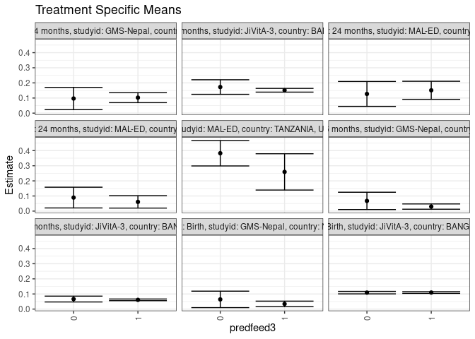

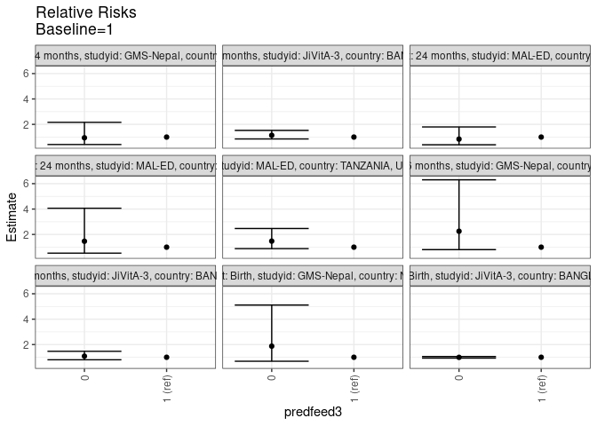

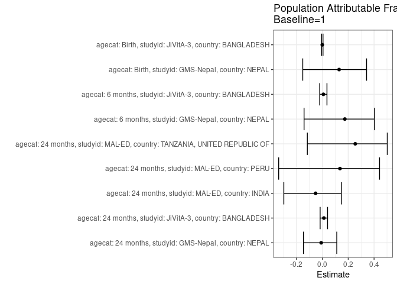

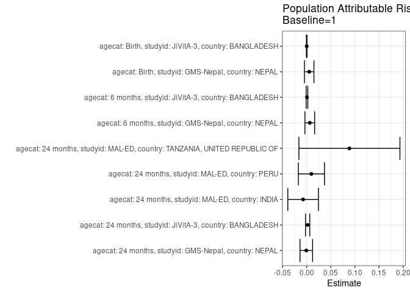

## Results Table

### Parameter: TSM

| agecat | studyid | country | intervention_level | baseline_level | estimate | ci_lower | ci_upper |
| --- | --- | --- | --- | --- | --- | --- | --- |
| Birth | GMS-Nepal | NEPAL | 1 | NA | 0.0342105 | 0.0159147 | 0.0525064 |
| Birth | GMS-Nepal | NEPAL | 0 | NA | 0.0641026 | 0.0096865 | 0.1185186 |
| Birth | JiVitA-3 | BANGLADESH | 1 | NA | 0.1094547 | 0.1036500 | 0.1152593 |
| Birth | JiVitA-3 | BANGLADESH | 0 | NA | 0.1088524 | 0.1006896 | 0.1170152 |
| 6 months | GMS-Nepal | NEPAL | 1 | NA | 0.0299728 | 0.0125080 | 0.0474375 |
| 6 months | GMS-Nepal | NEPAL | 0 | NA | 0.0675676 | 0.0103139 | 0.1248212 |
| 6 months | JiVitA-3 | BANGLADESH | 1 | NA | 0.0610415 | 0.0554864 | 0.0665966 |
| 6 months | JiVitA-3 | BANGLADESH | 0 | NA | 0.0663032 | 0.0469838 | 0.0856227 |
| 24 months | GMS-Nepal | NEPAL | 1 | NA | 0.1024845 | 0.0693152 | 0.1356538 |
| 24 months | GMS-Nepal | NEPAL | 0 | NA | 0.0967742 | 0.0230863 | 0.1704621 |
| 24 months | JiVitA-3 | BANGLADESH | 1 | NA | 0.1513077 | 0.1389392 | 0.1636762 |
| 24 months | JiVitA-3 | BANGLADESH | 0 | NA | 0.1725963 | 0.1243886 | 0.2208041 |
| 24 months | MAL-ED | INDIA | 1 | NA | 0.1510791 | 0.0913956 | 0.2107626 |
| 24 months | MAL-ED | INDIA | 0 | NA | 0.1269841 | 0.0445625 | 0.2094058 |
| 24 months | MAL-ED | PERU | 1 | NA | 0.0610687 | 0.0199596 | 0.1021778 |
| 24 months | MAL-ED | PERU | 0 | NA | 0.0895522 | 0.0210072 | 0.1580973 |
| 24 months | MAL-ED | TANZANIA, UNITED REPUBLIC OF | 1 | NA | 0.2593130 | 0.1392464 | 0.3793797 |
| 24 months | MAL-ED | TANZANIA, UNITED REPUBLIC OF | 0 | NA | 0.3828339 | 0.2986061 | 0.4670617 |

### Parameter: E(Y)

| agecat | studyid | country | intervention_level | baseline_level | estimate | ci_lower | ci_upper |
| --- | --- | --- | --- | --- | --- | --- | --- |
| Birth | GMS-Nepal | NEPAL | NA | NA | 0.0393013 | 0.0214863 | 0.0571164 |
| Birth | JiVitA-3 | BANGLADESH | NA | NA | 0.1093703 | 0.1036242 | 0.1151164 |
| 6 months | GMS-Nepal | NEPAL | NA | NA | 0.0362812 | 0.0188094 | 0.0537530 |
| 6 months | JiVitA-3 | BANGLADESH | NA | NA | 0.0615352 | 0.0561307 | 0.0669396 |
| 24 months | GMS-Nepal | NEPAL | NA | NA | 0.1015625 | 0.0713101 | 0.1318149 |
| 24 months | JiVitA-3 | BANGLADESH | NA | NA | 0.1531327 | 0.1409934 | 0.1652721 |
| 24 months | MAL-ED | INDIA | NA | NA | 0.1435644 | 0.0950890 | 0.1920397 |
| 24 months | MAL-ED | PERU | NA | NA | 0.0707071 | 0.0349120 | 0.1065021 |
| 24 months | MAL-ED | TANZANIA, UNITED REPUBLIC OF | NA | NA | 0.3478261 | 0.2788203 | 0.4168318 |

### Parameter: RR

| agecat | studyid | country | intervention_level | baseline_level | estimate | ci_lower | ci_upper |
| --- | --- | --- | --- | --- | --- | --- | --- |
| Birth | GMS-Nepal | NEPAL | 1 | 1 | 1.0000000 | 1.0000000 | 1.000000 |
| Birth | GMS-Nepal | NEPAL | 0 | 1 | 1.8737673 | 0.6870436 | 5.110307 |
| Birth | JiVitA-3 | BANGLADESH | 1 | 1 | 1.0000000 | 1.0000000 | 1.000000 |
| Birth | JiVitA-3 | BANGLADESH | 0 | 1 | 0.9944975 | 0.9359222 | 1.056739 |
| 6 months | GMS-Nepal | NEPAL | 1 | 1 | 1.0000000 | 1.0000000 | 1.000000 |
| 6 months | GMS-Nepal | NEPAL | 0 | 1 | 2.2542998 | 0.8061176 | 6.304126 |
| 6 months | JiVitA-3 | BANGLADESH | 1 | 1 | 1.0000000 | 1.0000000 | 1.000000 |
| 6 months | JiVitA-3 | BANGLADESH | 0 | 1 | 1.0861989 | 0.8031532 | 1.468995 |
| 24 months | GMS-Nepal | NEPAL | 1 | 1 | 1.0000000 | 1.0000000 | 1.000000 |
| 24 months | GMS-Nepal | NEPAL | 0 | 1 | 0.9442815 | 0.4128367 | 2.159855 |
| 24 months | JiVitA-3 | BANGLADESH | 1 | 1 | 1.0000000 | 1.0000000 | 1.000000 |
| 24 months | JiVitA-3 | BANGLADESH | 0 | 1 | 1.1406976 | 0.8531550 | 1.525152 |
| 24 months | MAL-ED | INDIA | 1 | 1 | 1.0000000 | 1.0000000 | 1.000000 |
| 24 months | MAL-ED | INDIA | 0 | 1 | 0.8405140 | 0.3931435 | 1.796962 |
| 24 months | MAL-ED | PERU | 1 | 1 | 1.0000000 | 1.0000000 | 1.000000 |
| 24 months | MAL-ED | PERU | 0 | 1 | 1.4664179 | 0.5291425 | 4.063899 |
| 24 months | MAL-ED | TANZANIA, UNITED REPUBLIC OF | 1 | 1 | 1.0000000 | 1.0000000 | 1.000000 |
| 24 months | MAL-ED | TANZANIA, UNITED REPUBLIC OF | 0 | 1 | 1.4763389 | 0.8825696 | 2.469580 |

### Parameter: PAR

| agecat | studyid | country | intervention_level | baseline_level | estimate | ci_lower | ci_upper |
| --- | --- | --- | --- | --- | --- | --- | --- |
| Birth | GMS-Nepal | NEPAL | 1 | NA | 0.0050908 | -0.0047405 | 0.0149221 |
| Birth | JiVitA-3 | BANGLADESH | 1 | NA | -0.0000844 | -0.0007201 | 0.0005514 |
| 6 months | GMS-Nepal | NEPAL | 1 | NA | 0.0063084 | -0.0038212 | 0.0164381 |
| 6 months | JiVitA-3 | BANGLADESH | 1 | NA | 0.0004936 | -0.0012307 | 0.0022180 |
| 24 months | GMS-Nepal | NEPAL | 1 | NA | -0.0009220 | -0.0139710 | 0.0121270 |
| 24 months | JiVitA-3 | BANGLADESH | 1 | NA | 0.0018250 | -0.0025955 | 0.0062456 |
| 24 months | MAL-ED | INDIA | 1 | NA | -0.0075148 | -0.0392898 | 0.0242603 |
| 24 months | MAL-ED | PERU | 1 | NA | 0.0096384 | -0.0174732 | 0.0367499 |
| 24 months | MAL-ED | TANZANIA, UNITED REPUBLIC OF | 1 | NA | 0.0885131 | -0.0162984 | 0.1933245 |

### Parameter: PAF

| agecat | studyid | country | intervention_level | baseline_level | estimate | ci_lower | ci_upper |
| --- | --- | --- | --- | --- | --- | --- | --- |
| Birth | GMS-Nepal | NEPAL | 1 | NA | 0.1295322 | -0.1516576 | 0.3420664 |
| Birth | JiVitA-3 | BANGLADESH | 1 | NA | -0.0007713 | -0.0065996 | 0.0050232 |
| 6 months | GMS-Nepal | NEPAL | 1 | NA | 0.1738760 | -0.1415465 | 0.4021437 |
| 6 months | JiVitA-3 | BANGLADESH | 1 | NA | 0.0080221 | -0.0203572 | 0.0356122 |
| 24 months | GMS-Nepal | NEPAL | 1 | NA | -0.0090779 | -0.1460736 | 0.1115420 |
| 24 months | JiVitA-3 | BANGLADESH | 1 | NA | 0.0119179 | -0.0172648 | 0.0402635 |
| 24 months | MAL-ED | INDIA | 1 | NA | -0.0523443 | -0.2981063 | 0.1468891 |
| 24 months | MAL-ED | PERU | 1 | NA | 0.1363141 | -0.3379192 | 0.4424526 |
| 24 months | MAL-ED | TANZANIA, UNITED REPUBLIC OF | 1 | NA | 0.2544750 | -0.1162363 | 0.5020701 |